# Laboratorio 1 — Manejo de canales de color con OpenCV

## 1. Configuración y carga de la imagen de prueba

```python
import cv2

RUTA_IMAGEN = "moscu.jpg"
imagen_original = cv2.imread(RUTA_IMAGEN)

if imagen_original is None:
    raise FileNotFoundError(f"No fue posible cargar: {RUTA_IMAGEN}")

alto, ancho, canales = imagen_original.shape
print("Imagen cargada correctamente")
print(f"Dimensiones: {ancho} x {alto}")
print(f"Cantidad de canales: {canales}")
```

```
Imagen cargada correctamente
Dimensiones: 300 x 300
Cantidad de canales: 3
```

[output not shown]

## Problema 1 — Activación selectiva de canales

```python
def activar_canales(imagen, color):
    """Devuelve una imagen BGR con los canales solicitados activos.

    Valores permitidos:
    1  = azul
    2  = verde
    3  = rojo
    10 = rojo + verde
    20 = verde + azul
    30 = azul + rojo
    """
    if imagen is None:
        raise ValueError("La imagen no puede ser None.")

    valores_validos = (1, 2, 3, 10, 20, 30)
    if color not in valores_validos:
        raise ValueError(f"color debe pertenecer a {valores_validos}")

    azul, verde, rojo = cv2.split(imagen)

    azul_cero = azul.copy()
    verde_cero = verde.copy()
    rojo_cero = rojo.copy()
    azul_cero[:] = 0
    verde_cero[:] = 0
    rojo_cero[:] = 0

    if color == 1:
        return cv2.merge((azul, verde_cero, rojo_cero))
    if color == 2:
        return cv2.merge((azul_cero, verde, rojo_cero))
    if color == 3:
        return cv2.merge((azul_cero, verde_cero, rojo))
    if color == 10:
        return cv2.merge((azul_cero, verde, rojo))
    if color == 20:
        return cv2.merge((azul, verde, rojo_cero))

    return cv2.merge((azul, verde_cero, rojo))
```

```python
nombres_colores = {
    1: "azul",
    2: "verde",
    3: "rojo",
    10: "rojo_verde",
    20: "verde_azul",
    30: "azul_rojo"
}

resultados_p1 = []
for valor, nombre in nombres_colores.items():
    salida = activar_canales(imagen_original, valor)
    archivo = f"p1_{nombre}.jpg"
    cv2.imwrite(archivo, salida)
    resultados_p1.append(salida)
    print(f"Generado: {archivo}")

fila_1 = cv2.hconcat(resultados_p1[:3])
fila_2 = cv2.hconcat(resultados_p1[3:])
resumen_p1 = cv2.vconcat((fila_1, fila_2))
cv2.imwrite("p1_resumen_canales.jpg", resumen_p1)
```

```
Generado: p1_azul.jpg
Generado: p1_verde.jpg
Generado: p1_rojo.jpg
Generado: p1_rojo_verde.jpg
Generado: p1_verde_azul.jpg
Generado: p1_azul_rojo.jpg
```

```
True
```

## Resultado de Problema 1

[figure not shown]

```python
import matplotlib.pyplot as plt


plt.imshow(cv2.cvtColor(resumen_p1, cv2.COLOR_BGR2RGB))
plt.axis("off")
plt.show()
```

## Problema 2 — Reconstrucción de una imagen desde tres escalas de grises 3D

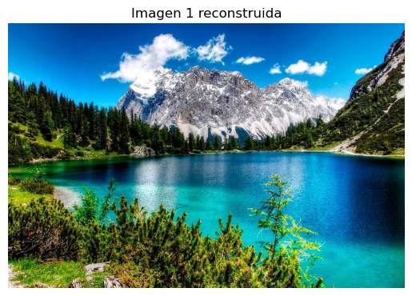

```python
import cv2
import matplotlib.pyplot as plt

# Cargar las tres imágenes como escala de grises
canal_azul = cv2.imread(
    "imagen1/imagen1_salida_gray_azul.jpg",
    cv2.IMREAD_GRAYSCALE
)

canal_verde = cv2.imread(
    "imagen1/imagen1_salida_gray_verde.jpg",
    cv2.IMREAD_GRAYSCALE
)

canal_rojo = cv2.imread(
    "imagen1/imagen1_salida_gray_rojo.jpg",
    cv2.IMREAD_GRAYSCALE
)

# Verificar que las imágenes fueron encontradas
if canal_azul is None:
    print("No se encontró la imagen del canal azul")
elif canal_verde is None:
    print("No se encontró la imagen del canal verde")
elif canal_rojo is None:
    print("No se encontró la imagen del canal rojo")
else:
    # OpenCV utiliza el orden BGR
    imagen_color = cv2.merge([
        canal_azul,
        canal_verde,
        canal_rojo
    ])

    # Guardar la imagen reconstruida
    cv2.imwrite(
        "imagen1/imagen1_reconstruida.jpg",
        imagen_color
    )

    # Mostrarla dentro del notebook
    plt.imshow(
        cv2.cvtColor(imagen_color, cv2.COLOR_BGR2RGB)
    )
    plt.title("Imagen 1 reconstruida")
    plt.axis("off")
    plt.show()
```

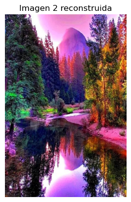

```python
import cv2
import matplotlib.pyplot as plt

# Cargar las tres imágenes como escala de grises
canal_azul = cv2.imread(
    "imagen2/imagen2_salida_gray_azul.jpg",
    cv2.IMREAD_GRAYSCALE
)

canal_verde = cv2.imread(
    "imagen2/imagen2_salida_gray_verde.jpg",
    cv2.IMREAD_GRAYSCALE
)

canal_rojo = cv2.imread(
    "imagen2/imagen2_salida_gray_rojo.jpg",
    cv2.IMREAD_GRAYSCALE
)

# Verificar que las imágenes fueron encontradas
if canal_azul is None:
    print("No se encontró la imagen del canal azul")
elif canal_verde is None:
    print("No se encontró la imagen del canal verde")
elif canal_rojo is None:
    print("No se encontró la imagen del canal rojo")
else:
    # OpenCV utiliza el orden BGR
    imagen_color = cv2.merge([
        canal_azul,
        canal_verde,
        canal_rojo
    ])

    # Guardar la imagen reconstruida
    cv2.imwrite(
        "imagen2/imagen2_reconstruida.jpg",
        imagen_color
    )

    # Mostrarla dentro del notebook
    plt.imshow(
        cv2.cvtColor(imagen_color, cv2.COLOR_BGR2RGB)
    )
    plt.title("Imagen 2 reconstruida")
    plt.axis("off")
    plt.show()
```

[figure not shown]

```python
import cv2
import matplotlib.pyplot as plt

# Cargar las tres imágenes como escala de grises
canal_azul = cv2.imread(
    "perro/perro_salida_gray_azul.jpg",
    cv2.IMREAD_GRAYSCALE
)

canal_verde = cv2.imread(
    "perro/perro_salida_gray_verde.jpg",
    cv2.IMREAD_GRAYSCALE
)

canal_rojo = cv2.imread(
    "perro/perro_salida_gray_rojo.jpg",
    cv2.IMREAD_GRAYSCALE
)

# Verificar que las imágenes fueron encontradas
if canal_azul is None:
    print("No se encontró la imagen del canal azul")
elif canal_verde is None:
    print("No se encontró la imagen del canal verde")
elif canal_rojo is None:
    print("No se encontró la imagen del canal rojo")
else:
    # OpenCV utiliza el orden BGR
    imagen_color = cv2.merge([
        canal_azul,
        canal_verde,
        canal_rojo
    ])

    # Guardar la imagen reconstruida
    cv2.imwrite(
        "perro/perro_reconstruida.jpg",
        imagen_color
    )

    # Mostrarla dentro del notebook
    plt.imshow(
        cv2.cvtColor(imagen_color, cv2.COLOR_BGR2RGB)
    )
    plt.title("Perro reconstruida")
    plt.axis("off")
    plt.show()
```

## Problema 3 — Escala de grises en tres dimensiones

```python
def escala_grises_tres_dimensiones(imagen):
    """Crea tres salidas 3D a partir de un gris promedio calculado manualmente."""
    if imagen is None:
        raise ValueError("La imagen no puede ser None.")

    azul, verde, rojo = cv2.split(imagen)

    # Conversión a 16 bits para evitar desbordamiento durante la suma.
    gris = ((azul.astype("uint16") + verde.astype("uint16") + rojo.astype("uint16")) // 3).astype("uint8")

    cero = gris.copy()
    cero[:] = 0

    salida_azul = cv2.merge((gris, cero, cero))
    salida_verde = cv2.merge((cero, gris, cero))
    salida_rojo = cv2.merge((cero, cero, gris))

    return salida_azul, salida_verde, salida_rojo

    # Se conserva una copia con el nombre esperado para los problemas 3 y 4.
    cv2.imwrite("Tokyo_prueba.jpg", imagen_original)
```

```python
tokyo = cv2.imread("Tokyo.jpg")
if tokyo is None:
    raise FileNotFoundError("No se encontró Tokyo_prueba.jpg")

p3_azul, p3_verde, p3_rojo = escala_grises_tres_dimensiones(tokyo)
cv2.imwrite("p3_tokyo_gris_azul.jpg", p3_azul)
cv2.imwrite("p3_tokyo_gris_verde.jpg", p3_verde)
cv2.imwrite("p3_tokyo_gris_rojo.jpg", p3_rojo)

resumen_p3 = cv2.hconcat((p3_azul, p3_verde, p3_rojo))
cv2.imwrite("p3_resumen_gris_3d.jpg", resumen_p3)
print("Se generaron las tres imágenes solicitadas.")
```

```
Se generaron las tres imágenes solicitadas.
```

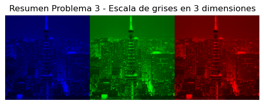

```python
plt.imshow(cv2.cvtColor(resumen_p3, cv2.COLOR_BGR2RGB))
plt.title("Resumen Problema 3 - Escala de grises en 3 dimensiones")
plt.axis("off")
plt.show()
```

## Problema 4 — Histogramas por canal y escala de grises

```python
def gris_promedio_manual(imagen):
    azul, verde, rojo = cv2.split(imagen)
    return ((azul.astype("uint16") + verde.astype("uint16") + rojo.astype("uint16")) // 3).astype("uint8")


def dibujar_histograma(canal, titulo, bgr_linea):
    """Construye una imagen del histograma y marca la media con una línea vertical."""
    histograma = cv2.calcHist([canal], [0], None, [256], [0, 256])
    media = cv2.mean(canal)[0]

    ancho_grafico = 768
    alto_grafico = 420
    margen_izq = 55
    margen_der = 20
    margen_sup = 50
    margen_inf = 45

    lienzo = cv2.resize(imagen_original, (ancho_grafico, alto_grafico))
    lienzo[:] = 255

    x0 = margen_izq
    y0 = alto_grafico - margen_inf
    x1 = ancho_grafico - margen_der
    y1 = margen_sup

    cv2.line(lienzo, (x0, y0), (x1, y0), (0, 0, 0), 1)
    cv2.line(lienzo, (x0, y0), (x0, y1), (0, 0, 0), 1)

    maximo = cv2.minMaxLoc(histograma)[1]
    puntos = []
    for intensidad in range(256):
        x = x0 + int(intensidad * (x1 - x0) / 255)
        frecuencia = float(histograma[intensidad][0])
        y = y0 - int((frecuencia / maximo) * (y0 - y1)) if maximo > 0 else y0
        puntos.append((x, y))

    for i in range(1, len(puntos)):
        cv2.line(lienzo, puntos[i - 1], puntos[i], bgr_linea, 2)

    x_media = x0 + int(media * (x1 - x0) / 255)
    cv2.line(lienzo, (x_media, y0), (x_media, y1), (0, 0, 0), 2)

    cv2.putText(lienzo, titulo, (20, 30), cv2.FONT_HERSHEY_SIMPLEX, 0.75, (0, 0, 0), 2)
    cv2.putText(lienzo, f"Media = {media:.2f}", (x_media + 5, y1 + 20), cv2.FONT_HERSHEY_SIMPLEX, 0.5, (0, 0, 0), 1)
    cv2.putText(lienzo, "0", (x0 - 5, y0 + 22), cv2.FONT_HERSHEY_SIMPLEX, 0.45, (0, 0, 0), 1)
    cv2.putText(lienzo, "255", (x1 - 25, y0 + 22), cv2.FONT_HERSHEY_SIMPLEX, 0.45, (0, 0, 0), 1)

    return lienzo, media
```

```python
azul, verde, rojo = cv2.split(tokyo)
gris_promedio = gris_promedio_manual(tokyo)

hist_azul, media_azul = dibujar_histograma(azul, "Histograma canal azul", (255, 0, 0))
hist_verde, media_verde = dibujar_histograma(verde, "Histograma canal verde", (0, 170, 0))
hist_rojo, media_rojo = dibujar_histograma(rojo, "Histograma canal rojo", (0, 0, 255))
hist_gris, media_gris = dibujar_histograma(gris_promedio, "Histograma escala de grises", (90, 90, 90))

cv2.imwrite("p4_histograma_azul.jpg", hist_azul)
cv2.imwrite("p4_histograma_verde.jpg", hist_verde)
cv2.imwrite("p4_histograma_rojo.jpg", hist_rojo)
cv2.imwrite("p4_histograma_gris.jpg", hist_gris)

fila_superior = cv2.hconcat((hist_azul, hist_verde))
fila_inferior = cv2.hconcat((hist_rojo, hist_gris))
resumen_p4 = cv2.vconcat((fila_superior, fila_inferior))
cv2.imwrite("p4_resumen_histogramas.jpg", resumen_p4)

print(f"Media azul:  {media_azul:.2f}")
print(f"Media verde: {media_verde:.2f}")
print(f"Media rojo:  {media_rojo:.2f}")
print(f"Media gris:  {media_gris:.2f}")
```

```
Media azul:  97.35
Media verde: 92.89
Media rojo:  95.82
Media gris:  95.04
```

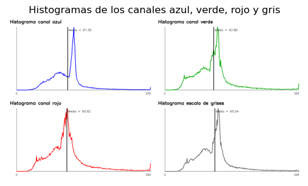

```python
plt.imshow(cv2.cvtColor(resumen_p4, cv2.COLOR_BGR2RGB))
plt.title("Histogramas de los canales azul, verde, rojo y gris")
plt.axis("off")
plt.show()
```

## Problema 5 — Escala de grises ponderada

El enfoque ponderado reconoce que el ojo humano no percibe todos los colores con la misma intensidad. Se asigna mayor peso al verde, un peso intermedio al rojo y menor peso al azul.

Una combinación habitual es:

[ I = 0.114B + 0.587G + 0.299R ]

No existe una única combinación; los pesos pueden variar según el estándar o la aplicación, pero normalmente suman 1.

```python
def escala_grises_ponderada(imagen, peso_azul=0.114, peso_verde=0.587, peso_rojo=0.299):
    """Calcula una escala de grises ponderada sin usar cv2.cvtColor."""
    if imagen is None:
        raise ValueError("La imagen no puede ser None.")

    suma_pesos = peso_azul + peso_verde + peso_rojo
    if abs(suma_pesos - 1.0) > 0.001:
        raise ValueError("Los pesos deben sumar aproximadamente 1.")

    azul, verde, rojo = cv2.split(imagen)
    gris = (
        azul.astype("float32") * peso_azul
        + verde.astype("float32") * peso_verde
        + rojo.astype("float32") * peso_rojo
    )
    return gris.astype("uint8")
```

```python
p5_gris_ponderado = escala_grises_ponderada(tokyo)
p5_gris_promedio = gris_promedio_manual(tokyo)

cv2.imwrite("p5_gris_promedio.jpg", p5_gris_promedio)
cv2.imwrite("p5_gris_ponderado.jpg", p5_gris_ponderado)

comparacion_p5 = cv2.hconcat((
    cv2.cvtColor(p5_gris_promedio, cv2.COLOR_GRAY2BGR),
    cv2.cvtColor(p5_gris_ponderado, cv2.COLOR_GRAY2BGR)
))
cv2.imwrite("p5_comparacion_grises.jpg", comparacion_p5)
print("Izquierda: promedio aritmético | Derecha: promedio ponderado")
```

```
Izquierda: promedio aritmético | Derecha: promedio ponderado
```

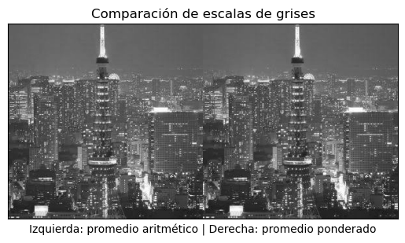

```python
plt.imshow(cv2.cvtColor(comparacion_p5, cv2.COLOR_BGR2RGB))
plt.title("Comparación de escalas de grises")
plt.xlabel("Izquierda: promedio aritmético | Derecha: promedio ponderado")
plt.xticks([])
plt.yticks([])
plt.show()
```

## Problema 6 — Espacio de color HSV

HSV representa los colores mediante tres componentes:

- **H — Hue o matiz:** identifica la familia del color. Se interpreta como una posición en un círculo cromático.
- **S — Saturation o saturación:** mide la pureza del color. Valores bajos se aproximan al gris; valores altos producen colores intensos.
- **V — Value o valor/brillo:** representa qué tan claro u oscuro es el color.

### Mapeo en OpenCV

En la representación HSV de OpenCV para imágenes de 8 bits:

- **H:** de 0 a 179, equivalente aproximadamente a 0°–360°.
- **S:** de 0 a 255.
- **V:** de 0 a 255.

Rangos aproximados de matiz:

| Color | Rango H aproximado en OpenCV |
| --- | --- |
| Rojo | 0–10 y 170–179 |
| Amarillo | 20–35 |
| Verde | 35–85 |
| Cian | 85–100 |
| Azul | 100–130 |
| Magenta | 140–170 |

El rojo aparece en dos extremos porque el matiz es circular. Para segmentar un color no basta con H: también es conveniente establecer mínimos de saturación y brillo para evitar incluir zonas grises, blancas o negras.

```python
hsv = cv2.cvtColor(tokyo, cv2.COLOR_BGR2HSV)
h, s, v = cv2.split(hsv)

cv2.imwrite("p6_h_matiz.jpg", h)
cv2.imwrite("p6_s_saturacion.jpg", s)
cv2.imwrite("p6_v_brillo.jpg", v)

resumen_p6 = cv2.hconcat((
    cv2.cvtColor(h, cv2.COLOR_GRAY2BGR),
    cv2.cvtColor(s, cv2.COLOR_GRAY2BGR),
    cv2.cvtColor(v, cv2.COLOR_GRAY2BGR)
))
cv2.imwrite("p6_componentes_hsv.jpg", resumen_p6)
print("Se generaron las representaciones de H, S y V.")
```

```
Se generaron las representaciones de H, S y V.
```

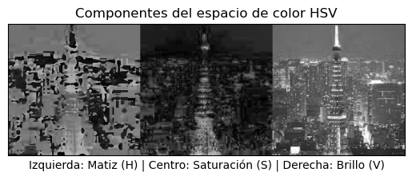

```python
plt.imshow(cv2.cvtColor(resumen_p6, cv2.COLOR_BGR2RGB))
plt.title("Componentes del espacio de color HSV")
plt.xlabel("Izquierda: Matiz (H) | Centro: Saturación (S) | Derecha: Brillo (V)")
plt.xticks([])
plt.yticks([])
plt.show()
```